# Sentiment Analysis

## Words As Data

Words are everywhere. Believe it or not, you are reading words right now! Given our penchant for taking things and making numbers out of them, you are probably already guessing that we can somehow make words tell a story with numbers. If that is what you are guessing, then you are absolutely correct.

We will start by pulling in our reviews again:

```r
library(dplyr)

library(rvest)

evilCzech = "https://www.yelp.com/biz/evil-czech-brewery-and-public-house-mishawaka"

evilCzechHTML = read_html(evilCzech)

ecRatings = evilCzechHTML %>%
  html_nodes(".review-wrapper .review-content .i-stars") %>%
  html_attr("title") %>%
  stringr::str_extract("[0-5]")

ecReviews = evilCzechHTML %>%
  html_nodes(".review-wrapper .review-content p") %>%
  html_text()

evilCzechData = data.frame(ratings = ecRatings,
                           reviews = ecReviews,
                           restaurant = "evil czech",
                           stringsAsFactors = FALSE)

fiddlers = "https://www.yelp.com/biz/fiddlers-hearth-south-bend"

fiddlersHTML = read_html(fiddlers)

fhRatings = fiddlersHTML %>%
  html_nodes(".review-wrapper .review-content .i-stars") %>%
  html_attr("title") %>%
  stringr::str_extract("[0-5]")

fhReviews = fiddlersHTML %>%
  html_nodes(".review-wrapper .review-content p") %>%
  html_text()

fhData = data.frame(ratings = fhRatings,
                    reviews = fhReviews,
                    restaurant = "fiddlers hearth",
                    stringsAsFactors = FALSE)

crookedEwe = "https://www.yelp.com/biz/crooked-ewe-brewery-and-ale-house-south-bend"

crookedEweHTML = read_html(crookedEwe)

ceRatings = crookedEweHTML %>%
  html_nodes(".review-wrapper .review-content .i-stars") %>%
  html_attr("title") %>%
  stringr::str_extract("[0-5]")

ceReviews = crookedEweHTML %>%
  html_nodes(".review-wrapper .review-content p") %>%
  html_text()

ceData = data.frame(ratings = ceRatings,
                    reviews = ceReviews,
                    restaurant = "crooked ewe",
                    stringsAsFactors = FALSE)

cambodianThai = "https://www.yelp.com/biz/cambodian-thai-south-bend"

cambodianThaiHTML = read_html(cambodianThai)

ctRatings = cambodianThaiHTML %>%
  html_nodes(".review-wrapper .review-content .i-stars") %>%
  html_attr("title") %>%
  stringr::str_extract("[0-5]")

ctReviews = cambodianThaiHTML %>%
  html_nodes(".review-wrapper .review-content p") %>%
  html_text()

ctData = data.frame(ratings = ctRatings,
                    reviews = ctReviews,
                    restaurant = "cambodian thai",
                    stringsAsFactors = FALSE)

corndance = "https://www.yelp.com/biz/corndance-tavern-mishawaka"

corndanceHTML = read_html(corndance)

cdRatings = corndanceHTML %>%
  html_nodes(".review-wrapper .review-content .i-stars") %>%
  html_attr("title") %>%
  stringr::str_extract("[0-5]")

cdReviews = corndanceHTML %>%
  html_nodes(".review-wrapper .review-content p") %>%
  html_text()

cdData = data.frame(ratings = cdRatings,
                    reviews = cdReviews,
                    restaurant = "corndance tavern",
                    stringsAsFactors = FALSE)

allReviews = dplyr::bind_rows(cdData, ceData, ctData, evilCzechData, fhData) %>%
  dplyr::mutate(ratings = as.numeric(ratings),
                wordCount = stringr::str_count(reviews, pattern = "\\S+"))
```

We will also be needing more than a few packages, so you can install them with the following:

```r
install.packages(c("SnowballC", "tm", "tidytext", "wordcloud2", "tokenizers", "DT"))
```

## Processing Text

Before we can even begin to dive into analyzing text, we must first process the text. Processing text involves several steps that will be combined in various ways, depending on what we are trying to accomplish.

### Stemming

Tense aside, are jumped, jump, and jumping the same thing? Yes, but what if we compare the actual strings? On a string comparison side, are they the same? No. We have a string with 6, 4, and 7 characters, respectively.

What if we remove the suffixes, “ed” and “ing” – we are left with three instances of “jump”? Now we have something that is equivalent in meaning and in a string sense. This is the goal of stemming.

Let’s take a look to see how this works (you will need to install `tm` and `SnowballC` first):

```r
library(tm)

library(SnowballC)

jumpingStrings = c("jump", "jumping", "jumped", "jumper")

tm::stemDocument(jumpingStrings)
```

```
[1] "jump"   "jump"   "jump"   "jumper"
```

We got exactly what we expected, right? You might have noticed that “jumper” did not get stemmed. Do you have any idea why? Let’s think through it together. “Jump”, “jumping”, and “jumped” are all verbs related to the act of jumping. “Jumper”, on the other hand, is a person who jumps – it is a noun. Martin Porter’s stemming algorithm works incredibly well!

Hopefully, this makes conceptual sense; however, we also need to understand why we need to do it. In a great many text-based methods, we are going to create a matrix that keeps track of every term (i.e., word) in every document – this is know as a document-term matrix. If we know that “jump”, “jumping”, and “jumped” all refer to the same thing, we want it just represented once within our document-term matrix.

Shall we take a look?

```r
library(tm)

documents = c("I like to jump",
              "I have jumped my whole life",
              "Jumping is in my blood",
              "I am a jumper")

documentsCorp = tm::SimpleCorpus(VectorSource(documents))

documentsDTM = DocumentTermMatrix(documentsCorp)

inspect(documentsDTM)
```

```
<<DocumentTermMatrix (documents: 4, terms: 9)>>
Non-/sparse entries: 9/27
Sparsity           : 75%
Maximal term length: 7
Weighting          : term frequency (tf)
Sample             :
    Terms
Docs blood have jump jumped jumper jumping life like whole
   1     0    0    1      0      0       0    0    1     0
   2     0    1    0      1      0       0    1    0     1
   3     1    0    0      0      0       1    0    0     0
   4     0    0    0      0      1       0    0    0     0
```

We can see that without stemming, we have 9 terms (things like “I”, “a”, and “to” get removed automatically). Let’s do some stemming now:

```r
documentsStemmed = stemDocument(documents)

documentsStemmed
```

```
[1] "I like to jump"            "I have jump my whole life"
[3] "Jump is in my blood"       "I am a jumper"
```

And now the document-term matrix:

```r
stemmedDocCorp = tm::SimpleCorpus(VectorSource(documentsStemmed))

stemmedDocDTM = DocumentTermMatrix(stemmedDocCorp)

inspect(stemmedDocDTM)
```

```
<<DocumentTermMatrix (documents: 4, terms: 7)>>
Non-/sparse entries: 9/19
Sparsity           : 68%
Maximal term length: 6
Weighting          : term frequency (tf)
Sample             :
    Terms
Docs blood have jump jumper life like whole
   1     0    0    1      0    0    1     0
   2     0    1    1      0    1    0     1
   3     1    0    1      0    0    0     0
   4     0    0    0      1    0    0     0
```

If we are trying to find documents that are covering similar content or talking about similar things, this document-term matrix will help to draw better conclusions, because it is clear that the first three documents are talking about the act of jumping and this document-term matrix reflects that.

### Stop Words

Some words do us very little good: articles, prepistions, and very high frequency words. These are all words that need to be removed. Fortunately, you don’t have to do this on your own – a great many dictionaries exist that contain words ready for removal.

```r
tm::stopwords("en")
```

```
  [1] "i"          "me"         "my"         "myself"     "we"
  [6] "our"        "ours"       "ourselves"  "you"        "your"
 [11] "yours"      "yourself"   "yourselves" "he"         "him"
 [16] "his"        "himself"    "she"        "her"        "hers"
 [21] "herself"    "it"         "its"        "itself"     "they"
 [26] "them"       "their"      "theirs"     "themselves" "what"
 [31] "which"      "who"        "whom"       "this"       "that"
 [36] "these"      "those"      "am"         "is"         "are"
 [41] "was"        "were"       "be"         "been"       "being"
 [46] "have"       "has"        "had"        "having"     "do"
 [51] "does"       "did"        "doing"      "would"      "should"
 [56] "could"      "ought"      "i'm"        "you're"     "he's"
 [61] "she's"      "it's"       "we're"      "they're"    "i've"
 [66] "you've"     "we've"      "they've"    "i'd"        "you'd"
 [71] "he'd"       "she'd"      "we'd"       "they'd"     "i'll"
```

[output cut: 20 more lines]

Removing stopwords takes little effort!

```r
documents = c("I like to jump",
              "I have jumped my whole life",
              "Jumping is in my blood",
              "I am a jumper")

tm::removeWords(documents, words = stopwords("en"))
```

```
[1] "I like  jump"          "I  jumped  whole life"
[3] "Jumping    blood"      "I   jumper"
```

We can even include custom stopwords:

```r
tm::removeWords(documents, words = c("blood", stopwords("en")))
```

```
[1] "I like  jump"          "I  jumped  whole life"
[3] "Jumping    "           "I   jumper"
```

There are many different stopword lists out there, so you might want to poke around just a little bit to find something that will suit the needs of a particular project.

```r
library(stopwords)
```

## Text Processing Tools

There are several R packages that will help us process text. The tm package is popular and automates most of our work. You already saw how we use the stemming and stopword removal functions, but tm is full of fun stuff and allows for one pass text processing.

```r
documents = c("I like to jump",
              "I have jumped my whole life",
              "Jumping is in my blood",
              "I am a jumper")

documentCorp = SimpleCorpus(VectorSource(documents))

stopWordRemoval = function(x) {
  removeWords(x, stopwords("en"))
}

textPrepFunctions = list(tolower,
                         removePunctuation,
                         stemDocument,
                         stopWordRemoval,
                         removeNumbers,
                         stripWhitespace)

documentCorp = tm_map(documentCorp, FUN = tm_reduce, tmFuns = textPrepFunctions)

documentCorp[1][[1]]$content
```

```
[1] "i like jump"
```

Once you get your text tidied up (or even before), you can produce some visualizations!

```r
library(tidytext)

library(wordcloud2)

allReviews %>%
  unnest_tokens(output = word, input = reviews) %>%
  anti_join(stop_words) %>%
  count(word, sort = TRUE) %>%
  filter(n > 10) %>%
  na.omit() %>%
  wordcloud2(shape = "cardioid")
```

[interactive chart not shown]

## Sentiment Analysis

Sentiment analysis is commonly used when we want to know the general *feelings* of what someone has written or said. Sentiment analysis is commonly seen applied to Twitter and other social media posts, but we can use it anywhere where people have written/said something (product reviews, song lyrics, final statements).

Sentiment can take many different forms: positive/negative affect, emotional states, and even financial contexts.

Let’s take a peak at some simple sentiment analysis.

### Simple Sentiment

Let’s consider the following statements:

```r
library(tidytext)

statement = "I dislike programming, but I really love R."

tokens = tibble(text = statement) %>%
  unnest_tokens(tbl = ., output = word, input = text)

tokens
```

```
# A tibble: 8 x 1
  word
  <chr>
1 i
2 dislike
3 programming
4 but
5 i
6 really
7 love
8 r
```

From there, we get every individual *token*. This brings us to a quick, but necessary, detour. When we are talking about text, tokens are simply elements that have some general meaning. We typically associate tokens with individual words, but we could go deeper than that (spaces, punctuation, *n*-grams). While we won’t dive into them too deeply, *n*-grams are also interesting. Just like our typical notion of *n*, an *n*-gram is an *n* length group of words. We can set *n* to be anything, but we would typically look at 2-gram and 3-grams chunks.

```r
tokenizers::tokenize_ngrams(statement, n = 2)
```

```
[[1]]
[1] "i dislike"           "dislike programming" "programming but"
[4] "but i"               "i really"            "really love"
[7] "love r"
```

These are helpful for looking at frequently occurring combinations of words.

Now back to the matter at hand.

Now, we can compare the tokens within our statement to some pre-defined dictionary of positive and negative words.

```r
library(tidyr)

tokens %>%
  inner_join(get_sentiments("bing")) %>%
  count(sentiment) %>%
  spread(sentiment, n, fill = 0) %>%
  mutate(sentiment = positive - negative)
```

```
# A tibble: 1 x 3
  negative positive sentiment
     <dbl>    <dbl>     <dbl>
1        1        1         0
```

When we use Bing’s dictionary, we see that we get one positive word (love) and negative word (dislike) with a neutral overall sentiment (a sentiment of 0 would indicate neutrality, while anything above 0 has an increasing amount of positivity and anything below 0 has an increasing amount of negativity).

Do you think that disklike and love are of the same magnitude (or *valence* in the parlance of our topic)? If I had to make a wild guess, I might say that love is stronger than dislike. Let’s switch out our sentiment library to get something with a little better notion of valence.

```r
tokens %>%
  inner_join(get_sentiments("afinn"))
```

```
# A tibble: 2 x 2
  word    score
  <chr>   <int>
1 dislike    -2
2 love        3
```

Now this looks a bit more interesting! “Love” has a stronger positive polarity than “dislike” has negative polarity. So, we could guess that we would have some positive sentiment.

If we divide the sum of our word sentiments by the number of words within the dictionary, we should get an idea of our sentences overall sentiment.

```r
tokens %>%
  inner_join(get_sentiments("afinn")) %>%
  summarize(n = nrow(.), sentSum = sum(score)) %>%
  mutate(sentiment = sentSum / n)
```

```
# A tibble: 1 x 3
      n sentSum sentiment
  <int>   <int>     <dbl>
1     2       1       0.5
```

Our sentiment of .5 tells us that our sentence is positive!

While these simple sentiment analyses provide some decent measures to the sentiment of our text, we are ignoring big chunks of our text by just counting keywords.

For example, it is probably fair to say that “really love” is stronger than just “love”. We might want to switch over to some techniques that consider *n*-grams and other text features to calculate sentiment.

### Smarter Sentiment Analysis

When we use sentiment analysis that is aware of context, valence (“love” is stronger than “like”), modifiers (e.g., “really love”), and adversative statements (“but,…”, “however,…”), we get a better idea about the real sentiment of the text.

We will use the *jockers* sentiment library, but many more are available. Depending on your exact needs, there are some dictionaries designed for different applications. A prime example, and one that should be near to our hearts, is the Loughran and McDonald dictionary for financial documents (e.g., SEC 10K filings). Tim Loughran and Bill McDonald are superstars in the Finance Department at Notre Dame! There are dictionaries designed to measure certain attitudes and opinions (e.g., disgust, excitedness, sadness) and even dictionaries to measure emoji sentiment.

Before we engage in our whole sentiment analysis, let’s take a look at a few things.

Here is the dictionary that *jockers* will use.

```r
lexicon::hash_sentiment_jockers
```

```
                 x     y
    1:     abandon -0.75
    2:   abandoned -0.50
    3:   abandoner -0.25
    4: abandonment -0.25
    5:    abandons -1.00
   ---
10734:     zealous  0.40
10735:      zenith  0.40
10736:        zest  0.50
10737:      zombie -0.25
10738:     zombies -0.25
```

You might want to use `View()` to get a complete look at what is happening in there.

We should also take a peak at our valence shifters:

```r
lexicon::hash_valence_shifters
```

```
              x y
  1: absolutely 2
  2:      acute 2
  3:    acutely 2
  4:      ain't 1
  5:       aint 1
 ---
136:    whereas 4
137:      won't 1
138:       wont 1
139:   wouldn't 1
140:    wouldnt 1
```

With all of that out of the way, let’s get down to the matter at hand:

```r
library(sentimentr)

library(lexicon)

library(magrittr)

statement = "I dislike programming, but I really love R."

sentiment(statement, polarity_dt = lexicon::hash_sentiment_jockers)
```

```
   element_id sentence_id word_count sentiment
1:          1           1          8  0.516188
```

We can see that we get a stronger sentiment score (even if only slightly) when we include more information within the sentence. While the first part of our sentence starts out with a negative word (dislike has a sentiment value of -1), we have an adversarial “but” that will downweight whatever is in the initial phrase and then we will have the amplified (from “really” with a weight of 2) sentiment of “love” (with a weight of .75 in our dictionary).

With all of this together, we get a better idea about the sentiment of our text.

### Revisiting Reviews

While the text that we have used so far serves its purpose as an example quite well, we can always take a look at other written words (maybe those reviews that we pulled last time will be interesting here).

From there, we can do just a little bit of data prep and then get our sentiment values:

```r
allReviews = allReviews %>%
  mutate(reviewID = 1:nrow(.)) # Just adding a reviewer id to the data.

reviewSentiment = sentiment(get_sentences(allReviews$reviews),
          polarity_dt = hash_sentiment_jockers)
```

The reviewSentiment object contains sentiment values for every sentence within every review. While useful on their own, it is helpful to group by the reviewer, summarize them by review and put them back into the original data.

```r
reviewSentiment = reviewSentiment %>%
  group_by(element_id) %>%
  summarize(meanSentiment = mean(sentiment))

allReviews = left_join(allReviews, reviewSentiment, by = c("reviewID" = "element_id"))
```

Now, we can engage in some exploration. Personally, I would love to see the review for that high word count:

```r
allReviews[which.max(allReviews$wordCount), ]
```

```
   ratings
11       5
                                                                                                                                                                                                                                                                                                            …
11 Inspired by the Potowatami tribe, "Keepers of the fire", Chef George Pesek creates his menu from local sources as much as possible including ranches, orchards, and vineyards. Just like the Potawatomi's Corn Dances were elaborate and exciting, so is the cuisine and ambiance here. It's unfortunate …
         restaurant wordCount reviewID meanSentiment
11 corndance tavern       841       11      0.138451
```

It would also be worth checking out the ratings by restaurant:

```r
allReviews %>%
  group_by(restaurant) %>%
  summarize(meanRating = mean(ratings),
            meanSentiment = mean(meanSentiment))
```

```
# A tibble: 5 x 3
  restaurant       meanRating meanSentiment
  <chr>                 <dbl>         <dbl>
1 cambodian thai         4.15         0.177
2 corndance tavern       4.25         0.181
3 crooked ewe            4.1          0.188
4 evil czech             4.1          0.203
5 fiddlers hearth        4.1          0.233
```

And let’s do some interactive work:

```r
library(DT)

sentimentBreaks = c(-.5, 0, .5)

breakColors = c('rgb(178,24,43)', 'rgb(239,138,98)', 'rgb(103,169,207)', 'rgb(33,102,172)')

datatable(allReviews, rownames = FALSE) %>%
  formatStyle("reviews", "meanSentiment", backgroundColor = styleInterval(sentimentBreaks, breakColors))
```

| ratings | reviews | restaurant | wordCount | reviewID | meanSentiment |
| --- | --- | --- | --- | --- | --- |
| 5 | This is my favorite place to Dine. Always very relaxing and the wait staff is attentive. Great desserts! | corndance tavern | 18 | 1 | 0.21789780400562 |
| 4 | I've been here once and I was rather impressed. The bison or buffalo bites (can't remember) were different from your normal appetizer but are flavorful. When people tell me they hate seafood I would h… | corndance tavern | 62 | 2 | -0.0359559757659253 |
| 4 | After coming back a few more times for work events, I'd give Corndance an additional star. I've had better luck with the wait staff who are still very casual (compared to LaSalle), but interactive and… | corndance tavern | 112 | 3 | 0.506891580340747 |
| 3 | So Corndance is a bit of an enigma for me. Higher price point than a typical restaurant, at least 100+$ for 2 people and for that I expect the best food,the best service, the best everything really. T… | corndance tavern | 236 | 4 | 0.0516002889918234 |
| 4 | This establishment is held to high esteem in the area, and a lot of people have raved about Corndance. I've always appreciated quality steak and I wanted to see what all of the hype was about. So I de… | corndance tavern | 330 | 5 | 0.129458653330767 |
| 5 | This is one of the best restaurants in the area! We love sitting at the bar for a nice relaxing dinner. There is always a great selection of wine and amazing craft cocktails. Don't forget to get the c… | corndance tavern | 48 | 6 | 0.320638298331428 |
| 5 | This place is pricey but it's delicious. Sometimes they've got good lunch specials that are not so pricey. If you want the dry aged beef plan ahead and make sure they got enough cuts for the day. Our … | corndance tavern | 80 | 7 | 0.180834507407508 |
| 3 | I wanted to like Corndance from the beginning. I've been to other restaurants run by the ownership and loved the experience. Corndance though just doesn't live up to the hype. Arrived for a reservatio… | corndance tavern | 120 | 8 | 0.167086741896721 |
| 5 | My husband and I have been coming to Corndance for the past two years since we moved to the area. We have had exceptional service and meals here on every occasion. We have brought friends in, and have… | corndance tavern | 49 | 9 | 0.230956957066189 |
| 3 | The food was good. The atmosphere seamed stuffy. The prices were high. I didn't have a warm fuzzy feeling when we left. I'd rather have great food and no atmosphere than the opposite. | corndance tavern | 33 | 10 | -0.00140393801097043 |

[output cut: 90 more lines]

And some visual checks.

First for ratings:

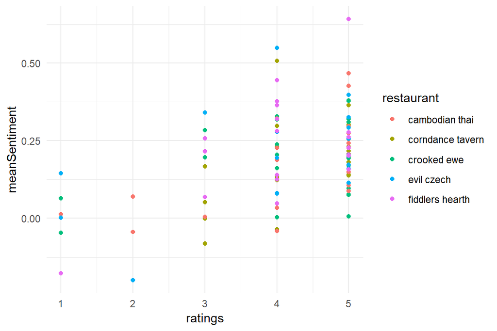

```r
library(ggplot2)

ggplot(allReviews, aes(ratings, meanSentiment, color = restaurant)) +
  geom_point() +
  theme_minimal()
```

And for word count:

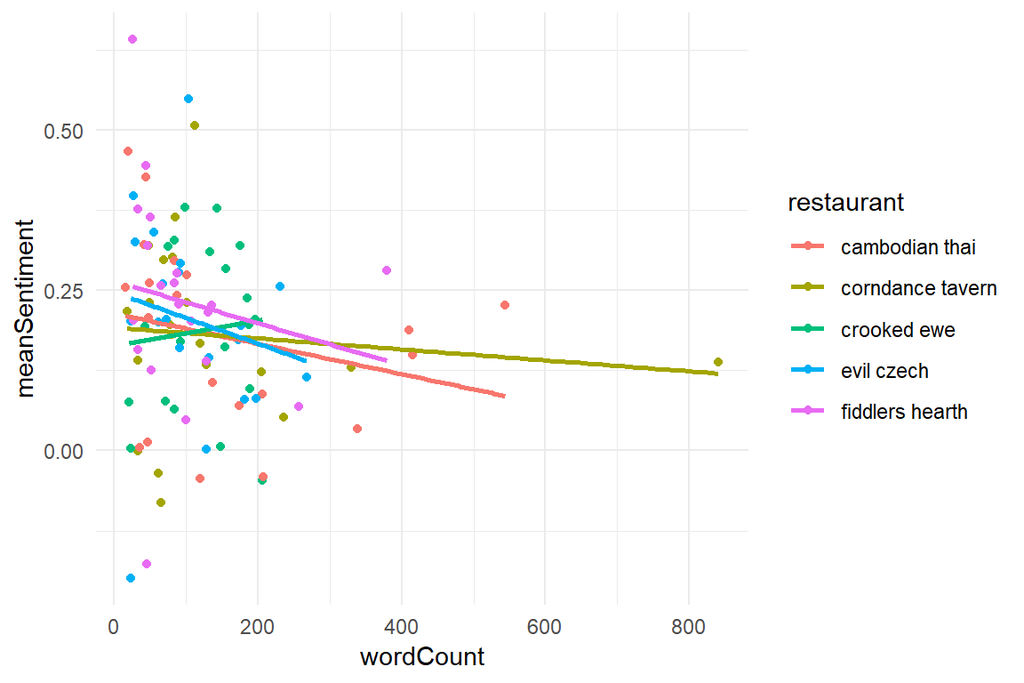

```r
ggplot(allReviews, aes(wordCount, meanSentiment, color = restaurant)) +
  geom_point() +
  geom_smooth(method = "lm", se = FALSE) +
  theme_minimal()
```